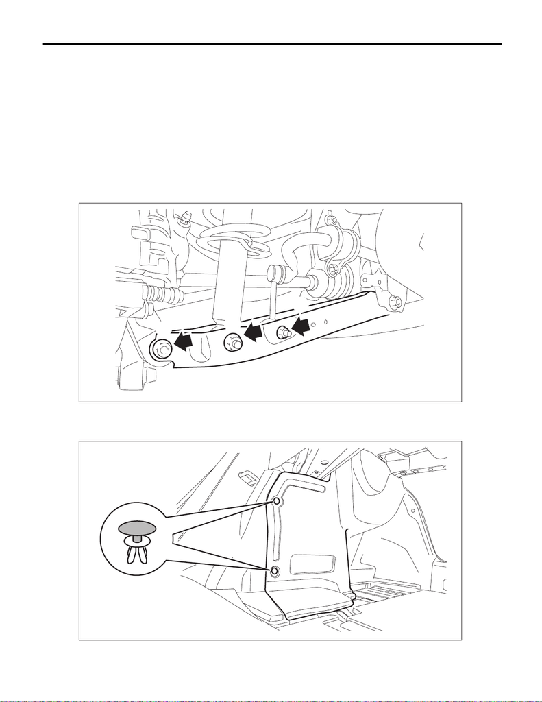

RS-27

Rear Shock Absorber

REAR SUSPENSION

9. Rear Shock Absorber

A: REMOVAL

1) Disconnect the ground cable from battery. <Ref. to NT-5, BATTERY, NOTE, Note.>

NOTE:

For models other than STI model, disconnect the ground terminal from battery sensor.

2) Lift up the vehicle, and then remove the rear wheels.

3) Remove the sensor assembly - headlight beam leveler. (Model with auto headlight beam leveler) <Ref. to

LI-74, REMOVAL, Rear Height Sensor.>

4) Remove the bolts and nuts, and lower the lateral link assembly - rear.

(1) Remove the nut and disconnect the rear stabilizer link assembly.

(2) Remove the bolts from the lower side of rear shock absorber assembly.

(3) Disconnect the housing assembly - rear axle from the lateral link assembly - rear.

5) Take out the trunk mat.

6) Tilt the rear seat backrest forward.

7) Remove the clips, and turn over the trim panel - trunk side.

RS-00402

(1)

(2)

(3)

RS-00409

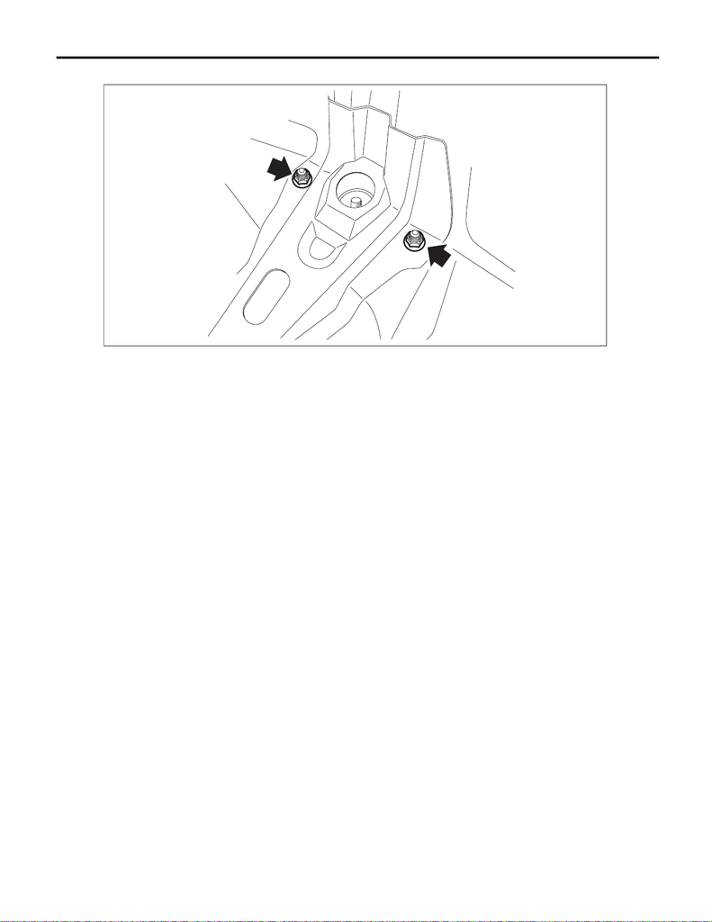

RS-28

Rear Shock Absorber

REAR SUSPENSION

8) Remove the nuts on the upper side of rear shock absorber assembly.

9) Lower the lateral link assembly - rear, and remove the rear shock absorber assembly.

B: INSTALLATION

CAUTION:

• For parts which are not reusable, always use new parts.

• Always tighten the bushing in the state where the vehicle is at curb weight and the wheels are in

full contact with the ground.

1) Install the rear shock absorber assembly.

(1) Lower the lateral link assembly - rear, and place the rear shock absorber assembly inside.

30 N·m (3.1 kgf-m, 22.1 ft-lb)

(3) Install the bolts on the lower side of rear shock absorber assembly.

Tightening torque:

85 N·m (8.7 kgf-m, 62.7 ft-lb)

(4) Install the lateral link assembly - rear and the stabilizer link assembly.

Tightening torque:

Refer to “COMPONENT” of “General Description” for the tightening torque. <Ref. to RS-3, COM-

PONENT, General Description.>

(5) Install the sensor assembly - headlight beam leveler. (Model with auto headlight beam leveler)

Tightening torque:

7.5 N·m (0.8 kgf-m, 5.5 ft-lb)

RS-00408

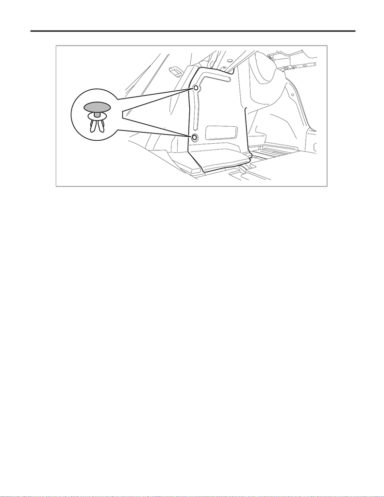

RS-29

Rear Shock Absorber

REAR SUSPENSION

2) Install the clips, and install the trim panel - trunk side.

3) Install the trunk mat, and return the rear seat backrest to the lock position.

4) Install the rear wheels and lower the vehicle.

Tightening torque:

120 N·m (12.2 kgf-m, 88.5 ft-lb)

5) Inspect the wheel alignment and adjust if necessary.

• Inspection: <Ref. to FS-10, INSPECTION, Wheel Alignment.>

• Adjustment: <Ref. to FS-15, ADJUSTMENT, Wheel Alignment.>

CAUTION:

When the wheel alignment has been adjusted, perform “VDC sensor midpoint setting mode” of the

VDC. <Ref. to VDC-16, ADJUSTMENT, VDC Control Module and Hydraulic Control Unit (VDCCM&H/

U).>

6) Connect the battery ground terminal. <Ref. to NT-5, BATTERY, NOTE, Note.>

NOTE:

For models other than STI model, connect the ground terminal to battery sensor.

7) Perform reinitialization of the auto headlight beam leveler system. (Model with auto headlight beam level-

er) <Ref. to LI-17, REINITIALIZATION, PROCEDURE, Auto Headlight Beam Leveler System.>

RS-00409

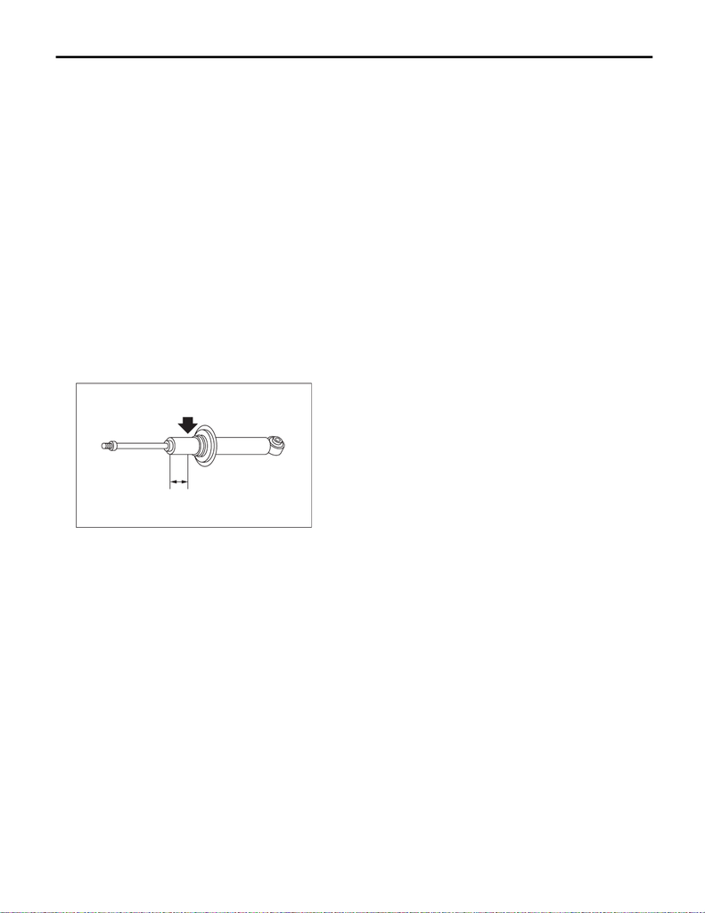

RS-30

Rear Shock Absorber

REAR SUSPENSION

C: DISASSEMBLY

Refer to “Front Strut” in “FRONT SUSPENSION” section for disassembly. <Ref. to FS-46, DISASSEMBLY,

Front Strut.>

D: ASSEMBLY

Refer to “Front Strut” in “FRONT SUSPENSION” section for assembly. <Ref. to FS-47, ASSEMBLY, Front

Strut.>

E: INSPECTION

Refer to “Front Strut” in “FRONT SUSPENSION” section for inspection procedures. <Ref. to FS-49, INSPEC-

TION, Front Strut.>

F: DISPOSAL

CAUTION:

• Before discarding the strut COMPL and the shock absorber COMPL, be sure to wear goggles to

protect eyes from gas, oil and cutting powder.

• Do not disassemble the strut COMPL and the shock absorber COMPL or throw them into flames.

• When discarding the strut COMPL and the shock absorber COMPL filled with gas, drill a hole on

them to purge the gas.

1) Place the shock absorber on a level surface with the piston rod fully expanded.

2) Make a hole into the specified position 30 mm (1.18 in) deep using a drill with 2 — 3 mm (0.08 — 0.12 in)

diameter.

(1) 40 mm (1.57 in)

(1)

RS-00135